# Serie de tiempo: análisis publicados por año

Unidad 3 · Regresión · Geoquímica de rocas con datos de EarthChem PetDB

Cristoffer Rumiguano, Ana Gabriela Fernández, Evelyn Bustamante, Jessica Haro, Jhonattan Ligña

Noviembre de 2026

> Proyecto estrictamente académico (Estadística y Probabilidades, FIGEMPA – UCE). Datos: EarthChem PetDB (CC BY 4.0), descargados el 13/10/2026. Web del proyecto: https://crisrumiguano-art.github.io/geoquimica-earthchem-ml/

## 1. Carga de datos

Se usa la base completa (159 760 análisis). Para cada par se toman solo las filas que tienen **los dos** datos: no se inventa ningún valor que falte.

```r
knitr::opts_chunk$set(echo = TRUE, message = FALSE, warning = FALSE, fig.align = "center")
if (!file.exists("data/earthchem_limpio.csv.gz")) {
  dir.create("data", showWarnings = FALSE)
  download.file("https://github.com/crisrumiguano-art/geoquimica-earthchem-ml/raw/main/data/earthchem_limpio.csv.gz", "data/earthchem_limpio.csv.gz", mode = "wb")
}
base <- read.csv(gzfile("data/earthchem_limpio.csv.gz", encoding = "UTF-8"), check.names = FALSE)
dim(base)
```

```
## [1] 159760     75
```

## 2. La serie

Cantidad de análisis de la base publicados cada año, de 1965 a 2024 (2025 está incompleto porque la base se descargó en octubre de 2026 y las publicaciones tardan en cargarse).

```r
anio <- base[["Publication Year"]]
conteo <- table(factor(anio, levels = 1965:2024))
serie <- ts(as.vector(conteo), start = 1965)           # serie de tiempo anual
knitr::kable(data.frame(anio = 1965:2024, analisis = as.vector(conteo))[seq(1, 60, by = 5), ], row.names = FALSE,
             caption = "Tabla N° 1: análisis publicados (cada 5 años)")
```

Tabla N° 1: análisis publicados (cada 5 años)

| anio | analisis |
| --- | --- |
| 1965 | 67 |
| 1970 | 420 |
| 1975 | 789 |
| 1980 | 5219 |
| 1985 | 4268 |
| 1990 | 2001 |
| 1995 | 2620 |
| 2000 | 2451 |
| 2005 | 2466 |
| 2010 | 4359 |
| 2015 | 6618 |
| 2020 | 2609 |

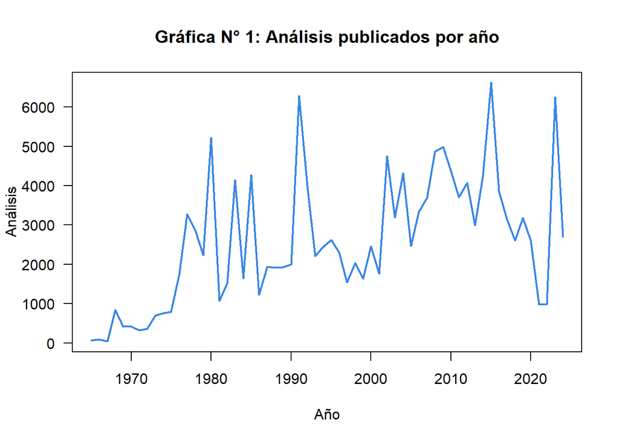

```r
plot(serie, lwd = 2, col = "#3987e5", las = 1, main = "Gráfica N° 1: Análisis publicados por año",
     xlab = "Año", ylab = "Análisis")
```

## 3. Componentes

- **Tendencia**: la serie crece de largo plazo (más laboratorios y técnicas más rápidas, como el ICP-MS desde 1990).
- **Ciclo**: subidas y bajadas de varios años, ligadas a grandes campañas de perforación oceánica (DSDP, ODP, IODP).
- **Aleatoriedad**: picos de un solo año por trabajos que publican miles de análisis juntos.
- **Estacionalidad**: no se puede ver, porque el dato es anual (la estacionalidad se repite dentro del año).

Por eso se usa un **modelo aditivo**: serie = tendencia + ciclo + aleatoriedad.

## 4. Tendencia por regresión

```r
t <- 1:length(serie)
lineal <- lm(as.vector(serie) ~ t)
cuadratica <- lm(as.vector(serie) ~ t + I(t^2))
c(R2_lineal = summary(lineal)$r.squared, R2_cuadratica = summary(cuadratica)$r.squared)
```

```
##     R2_lineal R2_cuadratica
##     0.3178747     0.4000717
```

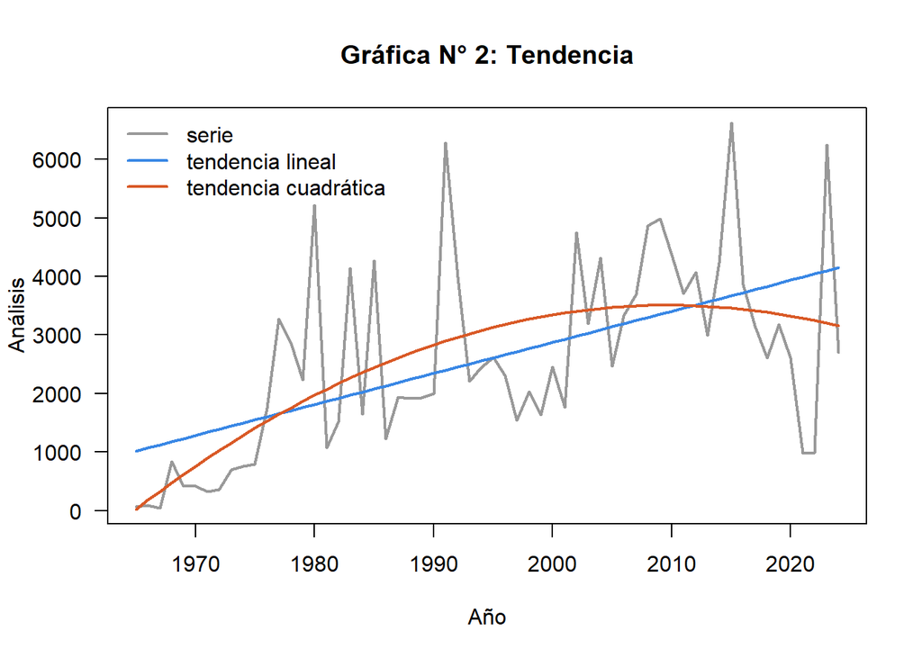

```r
plot(serie, lwd = 2, col = "gray60", las = 1, main = "Gráfica N° 2: Tendencia", xlab = "Año", ylab = "Análisis")
lines(1965:2024, fitted(lineal), col = "#3987e5", lwd = 2)
lines(1965:2024, fitted(cuadratica), col = "#d95926", lwd = 2)
legend("topleft", c("serie", "tendencia lineal", "tendencia cuadrática"), col = c("gray60", "#3987e5", "#d95926"),
       lwd = 2, bty = "n")
```

## 5. Medias móviles

Cada valor se reemplaza por el promedio de los 5 años centrados en él: se borra la aleatoriedad y queda la tendencia con el ciclo.

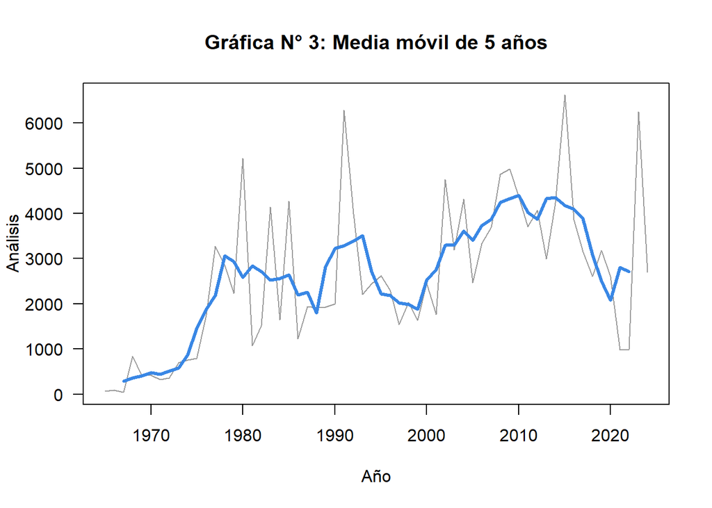

```r
movil <- stats::filter(serie, rep(1 / 5, 5), sides = 2)    # media móvil de 5 años
plot(serie, lwd = 1, col = "gray60", las = 1, main = "Gráfica N° 3: Media móvil de 5 años", xlab = "Año", ylab = "Análisis")
lines(movil, col = "#3987e5", lwd = 3)
```

## 6. Suavización exponencial

Cada pronóstico mezcla el último dato con el pronóstico anterior; `HoltWinters()` elige el peso (α) y, con tendencia, también β (método de Holt).

```r
holt <- HoltWinters(serie, gamma = FALSE)              # sin estacionalidad
c(alfa = holt$alpha, beta = holt$beta)
```

```
## alfa.alpha  beta.beta
##  0.2382774  0.0000000
```

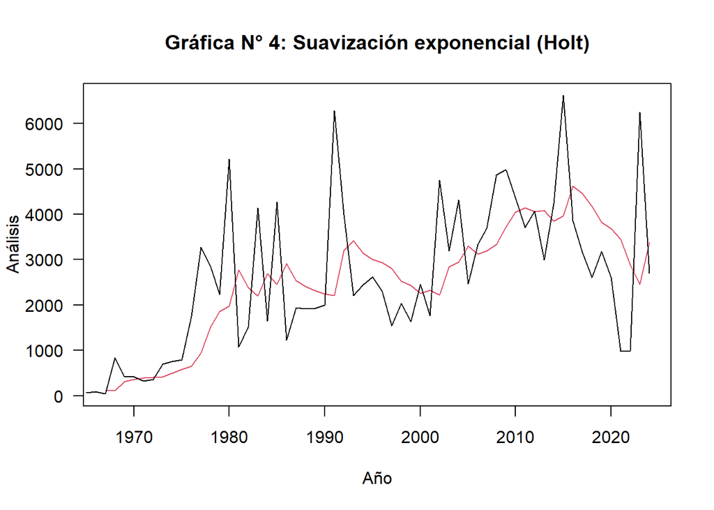

```r
plot(holt, las = 1, main = "Gráfica N° 4: Suavización exponencial (Holt)", xlab = "Año", ylab = "Análisis")
```

## 7. Pronóstico 2025–2029

```r
futuro <- 2025:2029
p_lineal <- predict(lineal, data.frame(t = length(serie) + 1:5))
p_cuad <- predict(cuadratica, data.frame(t = length(serie) + 1:5))
p_movil <- rep(mean(tail(serie, 5)), 5)                # media de los últimos 5 años
p_holt <- predict(holt, n.ahead = 5)
pron <- data.frame(anio = futuro, tendencia_lineal = round(p_lineal), tendencia_cuadratica = round(p_cuad),
                   media_movil = round(p_movil), holt = round(as.vector(p_holt)))
knitr::kable(pron, caption = "Tabla N° 2: pronóstico con las tres técnicas")
```

Tabla N° 2: pronóstico con las tres técnicas

| anio | tendencia_lineal | tendencia_cuadratica | media_movil | holt |
| --- | --- | --- | --- | --- |
| 2025 | 4201 | 3103 | 2707 | 3242 |
| 2026 | 4254 | 3048 | 2707 | 3264 |
| 2027 | 4307 | 2990 | 2707 | 3286 |
| 2028 | 4360 | 2928 | 2707 | 3308 |
| 2029 | 4413 | 2862 | 2707 | 3330 |

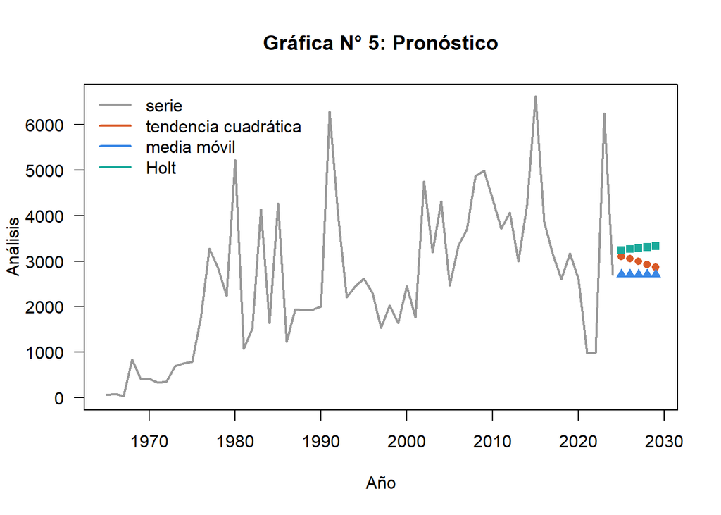

```r
plot(serie, xlim = c(1965, 2029), ylim = range(0, serie, pron[, -1]), lwd = 2, col = "gray60", las = 1,
     main = "Gráfica N° 5: Pronóstico", xlab = "Año", ylab = "Análisis")
lines(futuro, pron$tendencia_cuadratica, col = "#d95926", lwd = 2, type = "b", pch = 16)
lines(futuro, pron$media_movil, col = "#3987e5", lwd = 2, type = "b", pch = 17)
lines(futuro, pron$holt, col = "#1baa9b", lwd = 2, type = "b", pch = 15)
legend("topleft", c("serie", "tendencia cuadrática", "media móvil", "Holt"), col = c("gray60", "#d95926", "#3987e5", "#1baa9b"),
       lwd = 2, bty = "n")
```